# Fatal Encounters / Census Data Example

Kieran Healy

2023-02-03

The `Rmd` file etc is here: https://github.com/kjhealy/fatal_enc

```r
knitr::opts_chunk$set(echo = TRUE)

library(tidyverse) # Make sure you have the latest version
library(colorspace)
library(tidycensus) # You will need a Census API key. See: https://walker-data.com/tidycensus/articles/basic-usage.html
library(tigris)
library(sf)
library(googlesheets4) # You do *not* need a token for public read-only sheets.
gs4_deauth() # Just accessing public sheets, no need for an OAUTH token

library(here)

## https://fatalencounters.org/spreadsheets/
fe_sheet <- "https://docs.google.com/spreadsheets/d/1dKmaV_JiWcG8XBoRgP8b4e9Eopkpgt7FL7nyspvzAsE/edit#gid=0"


options(tigris_use_cache = TRUE)

## Census variables from 2021 ACS5
acs5vars <- load_variables(2021, "acs5", cache = TRUE)
```

## Get the Fatal Encounters Data

We’ll get the FE data live from the organization’s spreadsheet. For real applications we’d get a copy and save it locally to work with.

```r
## This will take a moment
fatal_df_raw <- read_sheet(ss = fe_sheet,
                       sheet = "Form Responses")
```

```
## ✔ Reading from "FATAL ENCOUNTERS DOT ORG SPREADSHEET (See Read me tab)".
```

```
## ✔ Range ''Form Responses''.
```

```r
fatal_df <- fatal_df_raw |>
  janitor::clean_names() |>
  rename(date = date_of_injury_resulting_in_death_month_day_year) |>
  select(unique_id:imputation_probability, date,
         location_of_injury_address:longitude) |>
  relocate(unique_id, latitude, longitude, everything())
```

Let’s do, say, census tracts for Los Angeles County, California.

Filter on the California cases and convert them to a spatial data frame. This will allow us to do the spatial join in a minute.

```r
fatal_ca <- fatal_df |>
    filter(state == "CA") |>
  st_as_sf(coords = c("longitude", "latitude"),
           crs = "NAD83") # This is the same as the Census CRS is going to be in.
```

Now we have,

```r
fatal_ca
```

```
## Simple feature collection with 4969 features and 14 fields
## Geometry type: POINT
## Dimension:     XY
## Bounding box:  xmin: -124.206 ymin: 30.52796 xmax: -71.42114 ymax: 41.91257
## Geodetic CRS:  NAD83
## # A tibble: 4,969 × 15
##    uniqu…¹ name  age    gender race  race_…² imput…³ date                locat…⁴
##  *   <dbl> <chr> <list> <chr>  <chr> <chr>   <chr>   <dttm>              <chr>
##  1   31492 Denn… <dbl>  Male   Euro… NA      NA      2021-12-30 00:00:00 435 E …
##  2   31409 Name… <NULL> Male   Hisp… Hispan… Not im… 2021-12-29 00:00:00 Carneg…
##  3   31410 Name… <NULL> Female Hisp… Hispan… Not im… 2021-12-29 00:00:00 Carneg…
##  4   31463 Robe… <dbl>  Male   Race… NA      NA      2021-12-27 00:00:00 E Miss…
##  5   31455 Enri… <dbl>  Male   Race… NA      NA      2021-12-26 00:00:00 2900 b…
##  6   31443 Dani… <dbl>  Male   Hisp… Hispan… Not im… 2021-12-23 00:00:00 12121 …
##  7   31448 Vale… <dbl>  Female Hisp… Hispan… Not im… 2021-12-23 00:00:00 12121 …
##  8   31429 Name… <dbl>  Male   Race… NA      NA      2021-12-20 00:00:00 Peabod…
##  9   31422 Marg… <dbl>  Male   Hisp… Hispan… Not im… 2021-12-18 00:00:00 900 E.…
## 10   31424 Rose… <dbl>  Male   Hisp… Hispan… Not im… 2021-12-18 00:00:00 2200 b…
## # … with 4,959 more rows, 6 more variables: location_of_death_city <chr>,
## #   state <chr>, location_of_death_zip_code <dbl>,
## #   location_of_death_county <chr>, full_address <chr>, geometry <POINT [°]>,
## #   and abbreviated variable names ¹unique_id, ²race_with_imputations,
## #   ³imputation_probability, ⁴location_of_injury_address
```

See how the call to `st_as_sf()` has used the latitude/longitude columns to convert the fatal encounters table in to a proper `sf` object with a CRS and a point geometry column. This is what will let us do spatial stuff below, like merging/joining data based on whether an FE case is within a specific census tract boundary.

## Get Census Bureau Data

Now get some tract-level data from the Census. We’ll use ACS data for LA County *only*. This next bit of code shows some handy ways to clean and reorganize the data that comes down from the Census API.

```r
my_vars <- tribble(
  ~variable, ~sn,
  "B25026_001", "pop_ohu",
  "B19013_001", "hhincome",
  "B02001_003", "total_black"
)

la_tracts <- get_acs(
  geography = "tract",
  variables = my_vars$variable,
  state = "CA",
  county = "Los Angeles",
  geometry = TRUE) |>
  # Split the NAME field into useful columns
  # The regular expression here will need to be changed
  # depending on the level of aggregation you are working with, because the
  # content of NAME will change correspondingly.
  separate_wider_regex(
    NAME,
    patterns = c(
      "Census Tract ", tract = "\\d+.\\d+", ", ",
      county = "[^,]+", ", ",
      state = ".*"
    )
  ) |>
  # add the short names and widen the var, estimate, and moe cols
  left_join(my_vars, by = "variable") |>
  # Drop original variable code
  select(-variable) |>
  pivot_wider(names_from = sn,
              values_from = c(estimate, moe),
              names_glue = "{sn}_{.value}") |>
  # tidy up
  relocate(county:geometry, .after = everything()) |>
  st_as_sf()
```

Now we have this:

```r
la_tracts
```

```
## Simple feature collection with 2498 features and 10 fields (with 3 geometries empty)
## Geometry type: MULTIPOLYGON
## Dimension:     XY
## Bounding box:  xmin: -118.9446 ymin: 32.80146 xmax: -117.6464 ymax: 34.8233
## Geodetic CRS:  NAD83
## # A tibble: 2,498 × 11
##    GEOID      tract total…¹ hhinc…² pop_o…³ total…⁴ hhinc…⁵ pop_o…⁶ county state
##    <chr>      <chr>   <dbl>   <dbl>   <dbl>   <dbl>   <dbl>   <dbl> <chr>  <chr>
##  1 060372946… 2946…      24   63348    4428      34   21488     871 Los A… Cali…
##  2 060372737… 2737      148  116393    2934     130   22958     357 Los A… Cali…
##  3 060372075… 2075…     189   90871    2022     127   23167     328 Los A… Cali…
##  4 060372421… 2421      577   23214    2648     177    6097     447 Los A… Cali…
##  5 060374081… 4081…      24  125129    2800      35   27906     400 Los A… Cali…
##  6 060372392… 2392…     738   46383    6570     311    7960    1254 Los A… Cali…
##  7 060377007… 7007        2  193639    3574       4   33348     614 Los A… Cali…
##  8 060374045… 4045…     150   62050    5026     106   15593     795 Los A… Cali…
##  9 060377019… 7019…     465   83379    4900     247   43498     607 Los A… Cali…
## 10 060375310… 5310        0   65904    5233      19   22462     771 Los A… Cali…
## # … with 2,488 more rows, 1 more variable: geometry <MULTIPOLYGON [°]>, and
## #   abbreviated variable names ¹total_black_estimate, ²hhincome_estimate,
## #   ³pop_ohu_estimate, ⁴total_black_moe, ⁵hhincome_moe, ⁶pop_ohu_moe
```

Notice how we have the covariates (population, income, black population, etc) spread out as columns of their own. Also see that the `geometry` column here is polygons, not points, because tracts are areas.

## Spatial Point-in-Polygon Merge

Because we only asked the Census for LA County tract data, but we have all the fatal encounters for CA, we want to attribute the tract-level information to those rows of the Fatal Encounters data that occured in LA county. Also we want the right tract. So we use the Lat/Lon data in the Fatal Encounters table to see which tract every encounter is in and merge on that basis. This is a spatial join.

We will end up with the Census-derived data attributed to the rows of the Fatal Encounters data (where appropriate).

```r
ca_pip <- st_join(fatal_ca, la_tracts, join = st_within)
```

Now we have,

```r
ca_pip
```

```
## Simple feature collection with 4970 features and 24 fields
## Geometry type: POINT
## Dimension:     XY
## Bounding box:  xmin: -124.206 ymin: 30.52796 xmax: -71.42114 ymax: 41.91257
## Geodetic CRS:  NAD83
## # A tibble: 4,970 × 25
##    uniqu…¹ name  age    gender race  race_…² imput…³ date                locat…⁴
##  *   <dbl> <chr> <list> <chr>  <chr> <chr>   <chr>   <dttm>              <chr>
##  1   31492 Denn… <dbl>  Male   Euro… NA      NA      2021-12-30 00:00:00 435 E …
##  2   31409 Name… <NULL> Male   Hisp… Hispan… Not im… 2021-12-29 00:00:00 Carneg…
##  3   31410 Name… <NULL> Female Hisp… Hispan… Not im… 2021-12-29 00:00:00 Carneg…
##  4   31463 Robe… <dbl>  Male   Race… NA      NA      2021-12-27 00:00:00 E Miss…
##  5   31455 Enri… <dbl>  Male   Race… NA      NA      2021-12-26 00:00:00 2900 b…
##  6   31443 Dani… <dbl>  Male   Hisp… Hispan… Not im… 2021-12-23 00:00:00 12121 …
##  7   31448 Vale… <dbl>  Female Hisp… Hispan… Not im… 2021-12-23 00:00:00 12121 …
##  8   31429 Name… <dbl>  Male   Race… NA      NA      2021-12-20 00:00:00 Peabod…
##  9   31422 Marg… <dbl>  Male   Hisp… Hispan… Not im… 2021-12-18 00:00:00 900 E.…
## 10   31424 Rose… <dbl>  Male   Hisp… Hispan… Not im… 2021-12-18 00:00:00 2200 b…
## # … with 4,960 more rows, 16 more variables: location_of_death_city <chr>,
## #   state.x <chr>, location_of_death_zip_code <dbl>,
## #   location_of_death_county <chr>, full_address <chr>, geometry <POINT [°]>,
## #   GEOID <chr>, tract <chr>, total_black_estimate <dbl>,
## #   hhincome_estimate <dbl>, pop_ohu_estimate <dbl>, total_black_moe <dbl>,
## #   hhincome_moe <dbl>, pop_ohu_moe <dbl>, county <chr>, state.y <chr>, and
## #   abbreviated variable names ¹unique_id, ²race_with_imputations, …
```

Select a few columns just to look:

```r
ca_pip |>
  select(unique_id, date, location_of_death_county, tract, county, GEOID, hhincome_estimate, total_black_estimate)
```

```
## Simple feature collection with 4970 features and 8 fields
## Geometry type: POINT
## Dimension:     XY
## Bounding box:  xmin: -124.206 ymin: 30.52796 xmax: -71.42114 ymax: 41.91257
## Geodetic CRS:  NAD83
## # A tibble: 4,970 × 9
##    unique_id date                location_o…¹ tract county GEOID hhinc…² total…³
##        <dbl> <dttm>              <chr>        <chr> <chr>  <chr>   <dbl>   <dbl>
##  1     31492 2021-12-30 00:00:00 Riverside    <NA>  <NA>   <NA>       NA      NA
##  2     31409 2021-12-29 00:00:00 San Bernard… <NA>  <NA>   <NA>       NA      NA
##  3     31410 2021-12-29 00:00:00 San Bernard… <NA>  <NA>   <NA>       NA      NA
##  4     31463 2021-12-27 00:00:00 San Diego    <NA>  <NA>   <NA>       NA      NA
##  5     31455 2021-12-26 00:00:00 Los Angeles  1813  Los A… 0603…  130125      98
##  6     31443 2021-12-23 00:00:00 Los Angeles  1239… Los A… 0603…   43289     236
##  7     31448 2021-12-23 00:00:00 Los Angeles  1239… Los A… 0603…   43289     236
##  8     31429 2021-12-20 00:00:00 Solano       <NA>  <NA>   <NA>       NA      NA
##  9     31422 2021-12-18 00:00:00 Los Angeles  2264… Los A… 0603…   35893     364
## 10     31424 2021-12-18 00:00:00 Los Angeles  2264… Los A… 0603…   38955      34
## # … with 4,960 more rows, 1 more variable: geometry <POINT [°]>, and
## #   abbreviated variable names ¹location_of_death_county, ²hhincome_estimate,
## #   ³total_black_estimate
```

You can see that `ca_pip` still pinpoints all incidents in California. But now the ones in LA have the tract variables we got from the ACS merged in. And we did this using Lat/Lon coordinates rather than trying to parse each address or whatever. Points not in LA County have `NA` for the ACS data, as we’d expect.

## Checking

But we still need to check! Let’s drop all the rows missing values on `tract`, which should give us all and only FEs in LA County tracts.

```r
la_pip <- ca_pip |>
  drop_na(tract)

la_pip
```

```
## Simple feature collection with 1319 features and 24 fields
## Geometry type: POINT
## Dimension:     XY
## Bounding box:  xmin: -118.7725 ymin: 33.73759 xmax: -117.7073 ymax: 34.80624
## Geodetic CRS:  NAD83
## # A tibble: 1,319 × 25
##    uniqu…¹ name  age    gender race  race_…² imput…³ date                locat…⁴
##      <dbl> <chr> <list> <chr>  <chr> <chr>   <chr>   <dttm>              <chr>
##  1   31455 Enri… <dbl>  Male   Race… NA      NA      2021-12-26 00:00:00 2900 b…
##  2   31443 Dani… <dbl>  Male   Hisp… Hispan… Not im… 2021-12-23 00:00:00 12121 …
##  3   31448 Vale… <dbl>  Female Hisp… Hispan… Not im… 2021-12-23 00:00:00 12121 …
##  4   31422 Marg… <dbl>  Male   Hisp… Hispan… Not im… 2021-12-18 00:00:00 900 E.…
##  5   31424 Rose… <dbl>  Male   Hisp… Hispan… Not im… 2021-12-18 00:00:00 2200 b…
##  6   31266 Devi… <dbl>  Male   Afri… Africa… Not im… 2021-11-23 00:00:00 512 N.…
##  7   31264 Name… <NULL> Male   Race… NA      NA      2021-11-22 00:00:00 700 bl…
##  8   31258 Davi… <dbl>  Male   Race… NA      NA      2021-11-21 00:00:00 2000 E…
##  9   31234 Wend… <dbl>  Female Hisp… Hispan… Not im… 2021-11-12 00:00:00 5756 W…
## 10   31194 Melk… <dbl>  Male   Euro… Europe… Not im… 2021-10-31 00:00:00 13802 …
## # … with 1,309 more rows, 16 more variables: location_of_death_city <chr>,
## #   state.x <chr>, location_of_death_zip_code <dbl>,
## #   location_of_death_county <chr>, full_address <chr>, geometry <POINT [°]>,
## #   GEOID <chr>, tract <chr>, total_black_estimate <dbl>,
## #   hhincome_estimate <dbl>, pop_ohu_estimate <dbl>, total_black_moe <dbl>,
## #   hhincome_moe <dbl>, pop_ohu_moe <dbl>, county <chr>, state.y <chr>, and
## #   abbreviated variable names ¹unique_id, ²race_with_imputations, …
```

We’re down to ~1300 incidents. Draw a quick map of the points:

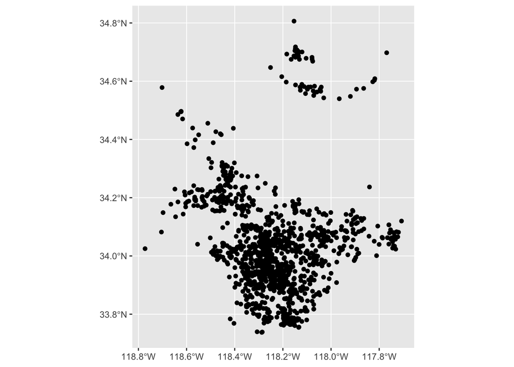

```r
ggplot(la_pip) +
  geom_sf()
```

Looks OK.

But! I also know there are some bad Lat/Lon records in the data, because I didn’t do it this way first. Here’s the `fatal_ca` table again, filtered manually by the location data in it:

```r
fatal_ca |>
  filter(location_of_death_county == "Los Angeles")
```

```
## Simple feature collection with 1321 features and 14 fields
## Geometry type: POINT
## Dimension:     XY
## Bounding box:  xmin: -118.8748 ymin: 33.73759 xmax: -76.77888 ymax: 40.34552
## Geodetic CRS:  NAD83
## # A tibble: 1,321 × 15
##    uniqu…¹ name  age    gender race  race_…² imput…³ date                locat…⁴
##  *   <dbl> <chr> <list> <chr>  <chr> <chr>   <chr>   <dttm>              <chr>
##  1   31455 Enri… <dbl>  Male   Race… NA      NA      2021-12-26 00:00:00 2900 b…
##  2   31443 Dani… <dbl>  Male   Hisp… Hispan… Not im… 2021-12-23 00:00:00 12121 …
##  3   31448 Vale… <dbl>  Female Hisp… Hispan… Not im… 2021-12-23 00:00:00 12121 …
##  4   31422 Marg… <dbl>  Male   Hisp… Hispan… Not im… 2021-12-18 00:00:00 900 E.…
##  5   31424 Rose… <dbl>  Male   Hisp… Hispan… Not im… 2021-12-18 00:00:00 2200 b…
##  6   31266 Devi… <dbl>  Male   Afri… Africa… Not im… 2021-11-23 00:00:00 512 N.…
##  7   31264 Name… <NULL> Male   Race… NA      NA      2021-11-22 00:00:00 700 bl…
##  8   31258 Davi… <dbl>  Male   Race… NA      NA      2021-11-21 00:00:00 2000 E…
##  9   31234 Wend… <dbl>  Female Hisp… Hispan… Not im… 2021-11-12 00:00:00 5756 W…
## 10   31194 Melk… <dbl>  Male   Euro… Europe… Not im… 2021-10-31 00:00:00 13802 …
## # … with 1,311 more rows, 6 more variables: location_of_death_city <chr>,
## #   state <chr>, location_of_death_zip_code <dbl>,
## #   location_of_death_county <chr>, full_address <chr>, geometry <POINT [°]>,
## #   and abbreviated variable names ¹unique_id, ²race_with_imputations,
## #   ³imputation_probability, ⁴location_of_injury_address
```

If we draw a map of this we see something is off in the FE dataset:

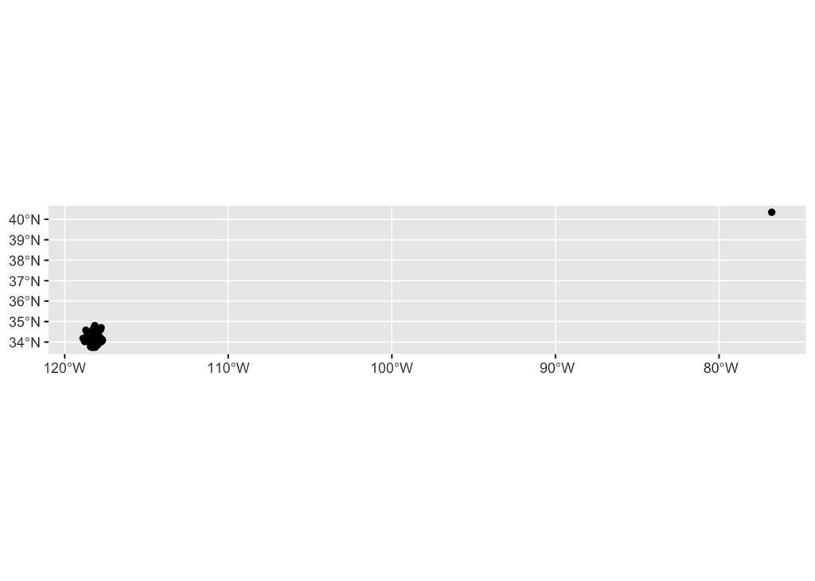

```r
fatal_ca |>
  filter(location_of_death_county == "Los Angeles") |>
  ggplot() +
  geom_sf()
```

```r
chk <- fatal_ca |>
  filter(location_of_death_county == "Los Angeles") |>
  st_coordinates() |>
  as_tibble() |>
  mutate(bad_y = Y > 36)

tmp <- fatal_ca |>
  filter(location_of_death_county == "Los Angeles") |>
  select(location_of_injury_address)
tmp[chk$bad_y,]
```

```
## Simple feature collection with 1 feature and 1 field
## Geometry type: POINT
## Dimension:     XY
## Bounding box:  xmin: -76.77888 ymin: 40.34552 xmax: -76.77888 ymax: 40.34552
## Geodetic CRS:  NAD83
## # A tibble: 1 × 2
##   location_of_injury_address             geometry
##   <chr>                               <POINT [°]>
## 1 6400 block Elmer Avenue    (-76.77888 40.34552)
```

This might be easy to miss in a join because the Lat/Lon doesn’t correspond to an LA County tract. The row would still be in the data but if we dropped on `tract` after the join we lose that case. But that is in fact a Fatal Encounter that happened in an LA County tract, according to the FE data. It’s just got the wrong Lat/Lon coordinates in that data. I’m going to ignore it for now because we’re just doing a quick example. But this is the sort of thing you have to be careful about. And also, I don’t like it that I found a bad geo record in the FE data on my very first random pass through it.

## Second cut at the pointwise map:

Back to `la_pip`:

```r
la_pip
```

```
## Simple feature collection with 1319 features and 24 fields
## Geometry type: POINT
## Dimension:     XY
## Bounding box:  xmin: -118.7725 ymin: 33.73759 xmax: -117.7073 ymax: 34.80624
## Geodetic CRS:  NAD83
## # A tibble: 1,319 × 25
##    uniqu…¹ name  age    gender race  race_…² imput…³ date                locat…⁴
##      <dbl> <chr> <list> <chr>  <chr> <chr>   <chr>   <dttm>              <chr>
##  1   31455 Enri… <dbl>  Male   Race… NA      NA      2021-12-26 00:00:00 2900 b…
##  2   31443 Dani… <dbl>  Male   Hisp… Hispan… Not im… 2021-12-23 00:00:00 12121 …
##  3   31448 Vale… <dbl>  Female Hisp… Hispan… Not im… 2021-12-23 00:00:00 12121 …
##  4   31422 Marg… <dbl>  Male   Hisp… Hispan… Not im… 2021-12-18 00:00:00 900 E.…
##  5   31424 Rose… <dbl>  Male   Hisp… Hispan… Not im… 2021-12-18 00:00:00 2200 b…
##  6   31266 Devi… <dbl>  Male   Afri… Africa… Not im… 2021-11-23 00:00:00 512 N.…
##  7   31264 Name… <NULL> Male   Race… NA      NA      2021-11-22 00:00:00 700 bl…
##  8   31258 Davi… <dbl>  Male   Race… NA      NA      2021-11-21 00:00:00 2000 E…
##  9   31234 Wend… <dbl>  Female Hisp… Hispan… Not im… 2021-11-12 00:00:00 5756 W…
## 10   31194 Melk… <dbl>  Male   Euro… Europe… Not im… 2021-10-31 00:00:00 13802 …
## # … with 1,309 more rows, 16 more variables: location_of_death_city <chr>,
## #   state.x <chr>, location_of_death_zip_code <dbl>,
## #   location_of_death_county <chr>, full_address <chr>, geometry <POINT [°]>,
## #   GEOID <chr>, tract <chr>, total_black_estimate <dbl>,
## #   hhincome_estimate <dbl>, pop_ohu_estimate <dbl>, total_black_moe <dbl>,
## #   hhincome_moe <dbl>, pop_ohu_moe <dbl>, county <chr>, state.y <chr>, and
## #   abbreviated variable names ¹unique_id, ²race_with_imputations, …
```

```r
# Add a "Fatal Encounter" column with the same value for every row, for the purposes of the map we're about to draw
la_pip_clean <- la_pip |>
  mutate(fe = "Fatal Encounter")
```

```r
la_pip_clean |>
  select(name, race, location_of_death_city, total_black_estimate, pop_ohu_estimate)
```

```
## Simple feature collection with 1319 features and 5 fields
## Geometry type: POINT
## Dimension:     XY
## Bounding box:  xmin: -118.7725 ymin: 33.73759 xmax: -117.7073 ymax: 34.80624
## Geodetic CRS:  NAD83
## # A tibble: 1,319 × 6
##    name                  race  locat…¹ total…² pop_o…³             geometry
##    <chr>                 <chr> <chr>     <dbl>   <dbl>          <POINT [°]>
##  1 Enrique Ruiz          Race… Los An…      98    3819 (-118.2277 34.14491)
##  2 Daniel Elena Lopez    Hisp… Los An…     236    4136 (-118.3975 34.18759)
##  3 Valentina Orellana-P… Hisp… Los An…     236    4136 (-118.3975 34.18759)
##  4 Margarito Lopez       Hisp… Los An…     364    5488 (-118.2574 34.01959)
##  5 Rosendo Olivio        Hisp… Los An…      34    3588 (-118.2619 34.02674)
##  6 Devin Edward Hall     Afri… Pasade…     175    3647 (-118.0893 34.15534)
##  7 Name withheld by pol… Race… West C…      96    6485  (-117.9345 34.0828)
##  8 David Koliba          Race… Willow…    1010    4655 (-118.2371 33.92882)
##  9 Wendy Carolina Flore… Hisp… Commer…      27    6042 (-118.1465 34.01778)
## 10 Melkon Michaelidis    Euro… Van Nu…     264    2779 (-118.4335 34.18634)
## # … with 1,309 more rows, and abbreviated variable names
## #   ¹location_of_death_city, ²total_black_estimate, ³pop_ohu_estimate
```

## Tracts + Points

For a model you might use e.g. an encounter-level table of data with tract-level or other features attributed to each case. Or alternatively e.g. a tract-level analysis with some summary of the number or type of encounters merged in and counted/averaged. (The unit of observation/analysis will matter a *lot*, substantively.) That’s why we do the spatial join above. But for this map we’ll need both tables—the `la_tracts` table and the `la_pip_clean` table. This is because one has the tract map shapes and the other has the point locations of the FEs. The base tract map looks like this:

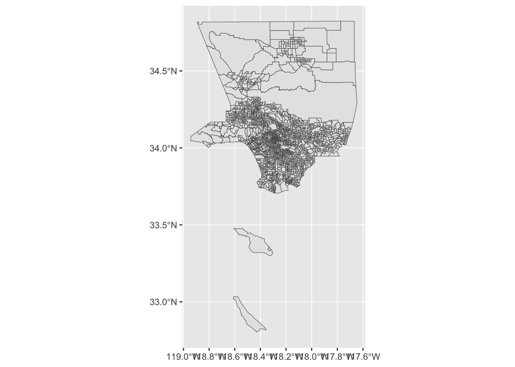

```r
la_tracts |>
  ggplot() +
  geom_sf()
```

We’re going to put the points on top in a separate layer. The two weird tracts in the south are Santa Catalina Island and San Clemente Island. Let’s get rid of those. (Again, real geography is messy …)

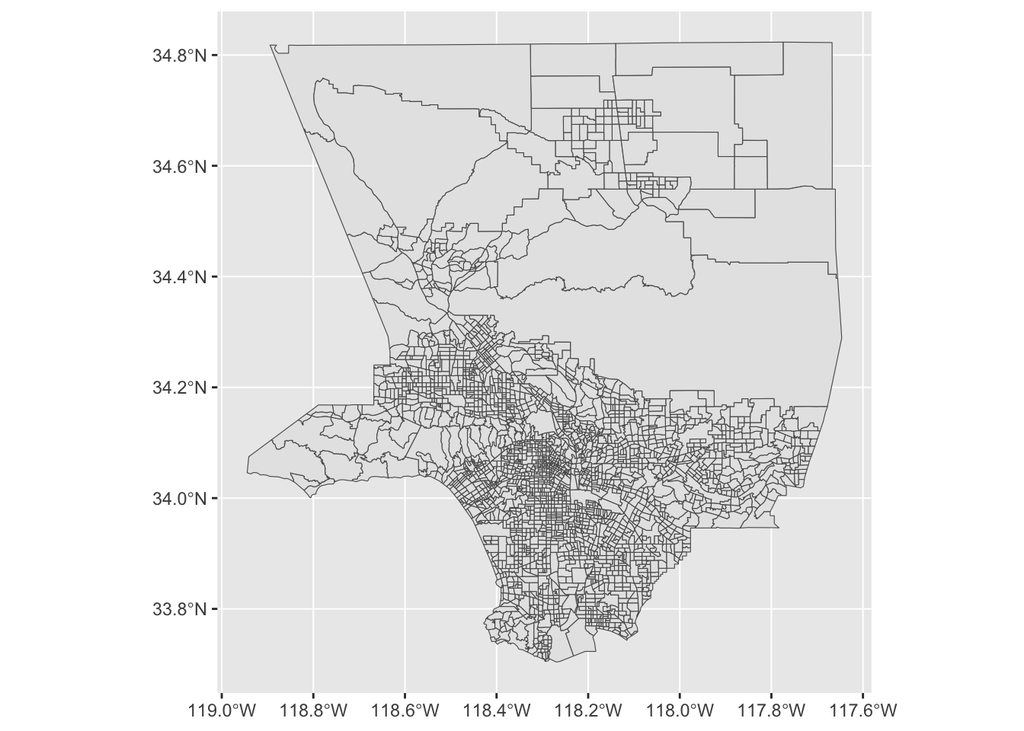

```r
la_tracts_clean <- la_tracts |>
  filter(!str_detect(tract, "599"))

la_tracts_clean |>
  ggplot() +
  geom_sf()
```

## Nicer Map

Finally, we’ll fix the projections so that they’re right for LA County.

```r
la_tracts_clean <- st_transform(la_tracts_clean, "EPSG:6423")
la_pip_clean <- st_transform(la_pip_clean, "EPSG:6423")
```

And draw a map:

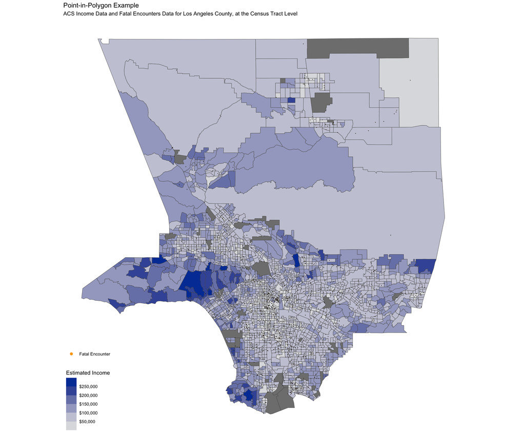

```r
p <- la_tracts_clean |>
  ggplot() +
  geom_sf(mapping = aes(fill = hhincome_estimate)) +
  geom_sf(data = la_pip_clean,
          mapping = aes(color = fe),
          fill = "orange",
          pch = 21,
          stroke = 0.2,
          size = 0.2) +
  scale_fill_binned_sequential(labels = scales::label_dollar()) +
  scale_color_manual(values = "black") +
  guides(colour = guide_legend(override.aes = list(size=2, color = "orange"))) +
  labs(fill = "Estimated Income",
       color = NULL,
       title = "Point-in-Polygon Example",
       subtitle = "ACS Income Data and Fatal Encounters Data for Los Angeles County, at the Census Tract Level") +
  kjhslides::kjh_theme_map()
print(p)
```

Save it out:

```r
ggsave(here("figures", "pip-example.pdf"), plot = p, width = 12, height = 10)
ggsave(here("figures", "pip-example.png"), plot = p, width = 12, height = 10, bg = "white")
```

We did this example at the tract level, and just for one county. Next steps would be to do this across a variety of different geographies—`tidycensus` supports everything the Census API can deliver.